# Instructions

# Question 9

En date du lundi 19 février 2018 à 10:00, le résultat du classement des pays participants aux Jeux olympiques de Pyeongchang se retrouve dans le fichier `olympic2.csv`. La première variable étant le nom du pays, la seconde est le nombre de médailles d'or, la troisième pour le nombre de médailles d'argent, finalement la dernière variable représente le nombre de médailles de bronze.

## a) [4 pts]

Le classement dans certains pays, comme les États-Unis, considère d'abord le nombre total de médailles, la nature de celles-ci ne servant qu'à départager d'éventuelles égalités.

Par exemple, pour savoir quel pays occupe le premier rang;

1. Il faut d’abord regarder le nombre total de médailles
2. Ensuite, le nombre de médailles d’or en cas d’égalité sur le nombre de médailles total
3. Ensuite le nombre de médailles argent, en cas d’égalité du nombre de médailles d’or
4. Ensuite le nombre de médailles de bronze, en cas d’égalité du nombre de médailles d’argent

Écrivez un code `SAS` que lorsqu’exécuté, il s’affiche un tableau qui classe les pays se retrouvant dans le fichier `olympic.csv` selon la règle décrite ci-dessus

## b) [4pts]

Il existe une autre règle qui utilise le total pondéré, on comptabilise toutes les médailles en donnant moins de "poids" aux médailles d'argent et de bronze, il est calculé selon le barème suivant: 1 médaille d'Or = 1 point, 1 médaille d'Argent = 0,5 point, 1 médaille de Bronze = 0,25 point. Ensuite on classe les pays selon ce pointage, le premier rang appartient au pays ayant le plus de points.

Écrivez un code `SAS` que lorsqu'exécuté, il s'affiche un tableau qui classe les pays se retrouvant dans le fichier `olympic.csv` selon la règle décrite ci-dessus

# Question 10

L'image ci-dessous est une capture d'écran d'un article paru dans La Presse+ le lundi 19 février 2018.

[figure not shown]

## a) [6 pts]

En vous servant du fichier `veloStats.csv`, vous voulez vérifier si cet article dit vrai. Pour simplifier l'exercice, considérons seulement les variables `Maisonneuve_1` et `Maisonneuve_2`. Écrivez un code `SAS` qui permet d'afficher le nombre total de passages par année à vélo sur les rues `Maisonneuve_1` et `Maisonneuve_2` de 2010 à 2016.

Votre résultat devrait contenir les mêmes données que le tableau ci-dessous;

[output not shown]

Nombre de bike commuter entre 2010 et 2016

| Date | Nombre |
| --- | --- |
| 2010 | 1,608,399 |
| 2011 | 1,754,273 |
| 2012 | 1,813,853 |
| 2013 | 1,693,599 |
| 2014 | 1,591,075 |
| 2015 | 756,878 |
| 2016 | 1,173,342 |

## b) [2 pts]

En vous basant sur le résultat en a), faites un graphique de type `vbar` qui nous donne un aperçu sur le nombre de navetteurs sur les rues `Maisonneuve_1` et `Maisonneuve_2` de 2010 à 2016.

Votre graphique devrait ressembler au graphique ci-dessous;

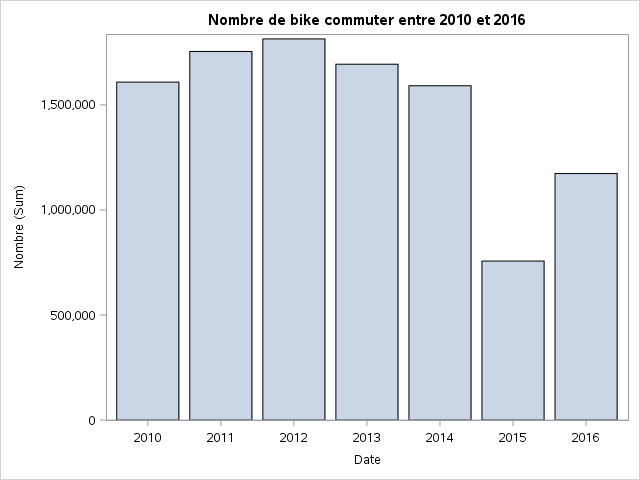